# MA589 Project 2

Wenbin Teng

October 5, 2018

1. Suppose you have a polynomial $p(x) = a_0 + a_1x + a_2x^2 + ... + a_nx^n$ and you wish to evaluate it at $x^*$. Instead of simply plugging-in $x^*$ in the expression for $p$, you could obtain $p(x^*)$ more efficiently using $Horner's$ $scheme$. The following R function takes a vector with coefficients $c(a_0, a_1, ..., a_n)$ and returns a function1 that takes $x^*$ as argument and returns $p(x^*)$.

```r
horner <- function (coef)
  function (x) {
    s <- 0
    for (i in seq(length(coef), 1, -1))
      s <- s * x + coef[i]
    s
  }

horner(c(3,-2,1))(2)
```

```
## [1] 3
```

1. Explain why $horner$ works; start by understanding how a small polynomial, say $c(3, -2, 1)$, is evaluated, and then provide a mathematical expression that summarizes how the computations are performed.

$$\begin{split}s & =(((0\cdot{x}+a_n)x+a_{n-1})x+a_{n-2})x+a_{n-3}...\\
& =((a_nx+a_{n-1})x+a_{n-2})x+a_{n-3}...\\
& =(a_nx^2+a_{n-1}x+a_{n-2})x+a_{n-3}...\\
& =a_nx^3+a_{n-1}x^2+a_{n-2}x+a_{n-3}...\\
& =...\\
& =a_nx^n+a_{n-1}x^{n-1}+a_{n-2}x^{n-2}+...+a_1x+a_0\end{split}$$

2. Use $horner$ to plot $p(x) = 2 - 4x - x^2/2+x^3$ for $x \in[-3,3]$. (Hint: check the code in the next problem, or see curve in R.)

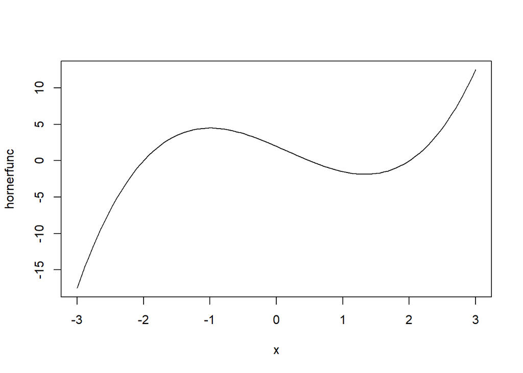

```r
hornerfunc <- horner(c(2,-4,-0.5,1))
plot.function(hornerfunc,from = -3, to = 3)
```

3. Implement Newton’s method to find the roots of $p$ from the previous item. Note that since the derivative of $p$ is also a polynomial, you can still use $horner$ to evaluate it. What roots do you find when starting at $x^{(0)} = -1.5$, $x^{(0)} = 0$, and $x^{(0)} = 1.5$? What happens when you start at $x_{(0)}=-1$?

```r
# derivative function
hornerdl <- function(coef)
  function(x){
    s <- 0
    for (i in seq(length(coef)-1,1,-1))
      s <- s *x + i * coef[i+1]
    s
  }
horner.newton.raphson <- function(coef,xzero, tolerance = 1e-10, max.iteration = 25) {
  hornerfunc <- horner(coef)
  hornerfdl <- hornerdl(coef)
  x.current <- xzero
  for (it in 1: max.iteration){
    x.next <- x.current - hornerfunc(x.current)/hornerfdl(x.current)
    if (abs((x.next-x.current)/x.current) < tolerance) break
    x.current <- x.next
  }
  return(x.next)
}
coef.new <- c(2, -4, -0.5, 1)
horner.newton.raphson(coef.new, -1.5);horner.newton.raphson(coef.new, 0)
```

```
## [1] -2
```

```
## [1] 0.5
```

```r
#horner.newton.raphson(coef.new, 1.5);horner.newton.raphson(coef.new, -1)
```

When $x^{(0)}=-1$, $p^{'}(x^{(0)}) = 0$, therefore, we can’t carry out Newton-Raphson algorithm to find out where the root is.

4. The $Legendre$ polynomial $Le_n$ of order $n$ is defined as
   $$Le_n(x) = \frac{1}{2^nn!}\frac{d^n}{dx^n}(x^2-1)^n$$

For instance, $Le_0(x) = 1$ and $Le_1(x) = x$, and we can derive the recurrent formulation $(n + 1)Le_{n+1}(x) = (2n + 1)xLe_n(x)-nLe_{n-1}(x)$. Using these facts, write a function that returns the coefficients of $Le_n$ to be used by $horner$. (*) Your function should exploit $memoization$, that is, it should cache the coefficients from previous calls to save computing time.

```r
legendre <- function(n){
  if (n==0) {
    lenext <- 1
  } else if (n==1) {
    lenext <- c(0,1)
  } else {
    lecurr0 <- c(1,rep(0,n));lecurr1 <- c(0,1,rep(0,(n-1)))
    for (i in 1:(n-1)){
      lenext <- (1/(i+1))*((2*i+1)*c(0,lecurr1[1:n])-i*lecurr0)
      lecurr0 <- lecurr1
      lecurr1 <- lenext
    }
  }
  lenext
}
legendre(0);legendre(1);legendre(2)
```

```
## [1] 1
```

```
## [1] 0 1
```

```
## [1] -0.5  0.0  1.5
```

2. A friend of yours wants to understand the behavior of a variable $y$ as a function of another variable $x$ and so collects the following data:

```r
# loading data
library(kableExtra)
project2p2 <- read.csv("C:/Users/wbten/OneDrive/Desktop/BU/Fall 2018/MA 589/project2p2.csv",header = T)
x <- unlist(project2p2[1,][2:14]);names(x) <- NULL
y <- unlist(project2p2[2,][2:14]);names(y) <- NULL
```

$$\left[\begin{array}
{lrrrrrrrrrrrrr}
i & 1 & 2 & 3 & 4 & 5 & 6 & 7 & 8 & 9 & 10 & 11 & 12 & 13\\
x & -3.0 & -2.5 & -2.0 & -1.5 & -1.0 & -0.5 & 0.0 & 0.5 & 1 & 1.5 & 2.0 & 2.5 & 3\\
y & -17.0 & -7.0 & 0.5 & 3.0 & 5 & 4.0 & 2.5 & -0.5 & -2.0 & -2.0 & 0.5 & 5.0 & 12.0\\
\end{array}\right]$$

Your friend knows that $y = p(x)$ where $p$ is a polynomial of (hopefully) low degree. You suggest him to fit a regression assuming that the degree is four to find the coefficients $\beta$:
$$y_i = \beta_0 + \beta_1x_i + \beta_2x^2_i + \beta_3x^3_i + \beta_4x^4_i,i = 1,...,13$$

1. Build matrices for $X$–this is not simply $x$, but the “predictors” in the expression above; it is a $Vandermonde$ matrix–and y. Now find $X^TX$ and $X^Ty$ and assemble the tableau:
   $$T = \left[\begin{array}
   {rr}
   X^TX & X^Ty \\
   y^TX & y^Ty \\
   \end{array}\right]$$

```r
vandermonde <- function(x, d) outer(x, 0:d, `^`)
X <- vandermonde(x, 4)
T11 <- crossprod(X,X);T12 <- crossprod(X,y);T21 <- crossprod(y,X); T22 <- crossprod(y,y)
Tableau <- rbind(cbind(T11,T12),cbind(T21,T22))
Tableau
```

```
##         [,1]    [,2]     [,3]      [,4]       [,5]      [,6]
## [1,]  13.000   0.000   45.500    0.0000   284.3750    4.0000
## [2,]   0.000  45.500    0.000  284.3750     0.0000  100.2500
## [3,]  45.500   0.000  284.375    0.0000  2099.0938  -47.3750
## [4,]   0.000 284.375    0.000 2099.0938     0.0000  946.0625
## [5,] 284.375   0.000 2099.094    0.0000 16739.0234 -458.8438
## [6,]   4.000 100.250  -47.375  946.0625  -458.8438  572.0000
```

```r
SWEEP <- function(T,k) {
  stopifnot(k <= nrow(T))
  newT <- matrix(NA,nrow(T),ncol(T))
  D <- T[k, k]
  for (i in 1:nrow(T)) {
    for (j in 1:ncol(T)) {
      if (i != k & j != k) {
        newT[i, j] <- T[i, j] - (T[i,k]*T[k,j]/D)
      } else if (i == k & j != k) {
        newT[k, j] <- T[k, j]/D
      } else if (i != k & j == k) {
        newT[i, k] <- -T[i, k]/D
      } else if (i == k & j == k) {
        newT[k, k] <- 1/D
      }
    }
  }
  return(newT)
}
for (k in 1:5) {
  print(SWEEP(SWEEP(Tableau,k),k) == Tableau)
}
```

```
##      [,1] [,2] [,3] [,4] [,5] [,6]
## [1,] TRUE TRUE TRUE TRUE TRUE TRUE
## [2,] TRUE TRUE TRUE TRUE TRUE TRUE
## [3,] TRUE TRUE TRUE TRUE TRUE TRUE
## [4,] TRUE TRUE TRUE TRUE TRUE TRUE
## [5,] TRUE TRUE TRUE TRUE TRUE TRUE
## [6,] TRUE TRUE TRUE TRUE TRUE TRUE
##      [,1] [,2] [,3] [,4] [,5] [,6]
## [1,] TRUE TRUE TRUE TRUE TRUE TRUE
## [2,] TRUE TRUE TRUE TRUE TRUE TRUE
## [3,] TRUE TRUE TRUE TRUE TRUE TRUE
## [4,] TRUE TRUE TRUE TRUE TRUE TRUE
## [5,] TRUE TRUE TRUE TRUE TRUE TRUE
## [6,] TRUE TRUE TRUE TRUE TRUE TRUE
##       [,1] [,2] [,3] [,4] [,5]  [,6]
```

[output cut: 20 more lines]

3. Every time we sweep a row that corresponds to a predictor, we include it in the regression (or exclude it if it is already in.) Having this in mind, how do you explain the output from the following code? What is being plotted at each k? What is being printed at each k?

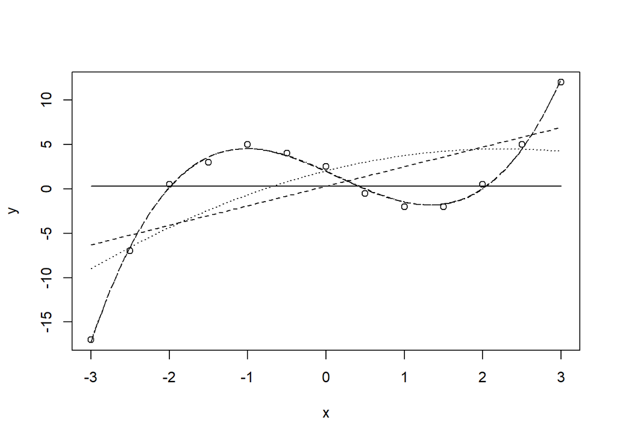

```
## [1]   1.0000 570.7692
## [1]   2.0000 349.8887
## [1]   3.0000 319.7837
## [1] 4.000000 2.517982
## [1] 5.000000 2.486895
```

```r
T <- Tableau
plot(x, y)
a <- seq(-3, 3, length.out = 100)
p <- ncol(T) - 1
for (k in 1:p) {
  T <- SWEEP(T, k)
  lines(a, horner(T[1:k, p + 1])(a), lty = k)
  print(c(k, T[p + 1, p + 1]))
}
```

3. The SWEEP operator can also be useful when deriving matrix identities. Suppose we have normal random vectors $\mathbf{x}$ and $\mathbf{y}$ with joint distribution:

$$\left[\begin{array}
{rr}
\mathbf{x} \\
\mathbf{y} \\
\end{array}\right]
\sim N\Bigg(
\left[\begin{array}
{rr}
\mu_x \\
\mu_y \\
\end{array}\right]
,
\left[\begin{array}
{rr}
\ \Sigma_{xx} & \Sigma_{xy} \\
\ \Sigma_{xy}^\top & \Sigma_{yy} \\
\end{array}\right]\Bigg)$$
To obtain the inverse of the joint variance matrix of $\mathbf{x}$ and $\mathbf{y}$ we can apply the SWEEP operator in two steps:

Step 1: Let $D = \Sigma_{xx}$

Step 2: Divide xx-block and xy-block by $D$, we have:

$$\left[\begin{array}
{rr}
\ \Sigma_{xx} & \Sigma_{xy} \\
\ \Sigma_{xy}^\top & \Sigma_{yy} \\
\end{array}\right]
\longrightarrow
\left[\begin{array}
{rr}
\ I & \Sigma_{xx}^{-1} \Sigma_{xy} \\
\ \Sigma_{xy}^\top & \Sigma_{yy} \\
\end{array}\right]$$

Step 3: For yx-block and yy-block, let $B=\Sigma_{xy}^\top$. Substract $B$ times xx-block and xy-block (after step 2) from yx-block and yy-block, and set yx-block to $-DB^{-1}$we have:

$$\left[\begin{array}
{rr}
\ \Sigma_{xx} & \Sigma_{xy} \\
\ \Sigma_{xy}^\top & \Sigma_{yy} \\
\end{array}\right]
\longrightarrow
\left[\begin{array}
{rr}
\ I & \Sigma_{xx}^{-1} \Sigma_{xy} \\
\ \Sigma_{xy}^\top & \Sigma_{yy} \\
\end{array}\right]
\longrightarrow
\left[\begin{array}
{rr}
\ I & \Sigma_{xx}^{-1} \Sigma_{xy} \\
\ -\Sigma_{xy}^\top\Sigma_{xx}^{-1} & \Sigma_{yy}-\Sigma_{xy}^\top\Sigma_{xx}^{-1} \Sigma_{xy} \\
\end{array}\right]$$

Step 4: Set xx-block to $(\Sigma_{xx})^{-1}$, we obtain the result for the first SWEEP

$$\left[\begin{array}
{rr}
\ \Sigma_{xx} & \Sigma_{xy} \\
\ \Sigma_{xy}^\top & \Sigma_{yy} \\
\end{array}\right]
\longrightarrow
\left[\begin{array}
{rr}
\ \Sigma_{xx}^{-1} & \Sigma_{xx}^{-1} \Sigma_{xy} \\
\ -\Sigma_{xy}^\top\Sigma_{xx}^{-1} & S:=\Sigma_{yy}-\Sigma_{xy}^\top\Sigma_{xx}^{-1} \Sigma_{xy} \\
\end{array}\right]$$

So, $S=\Sigma_{yy}-\Sigma_{xy}^\top(\Sigma_{xx})^{-1} \Sigma_{xy}$

2. Similarly, show that, after the second SWEEP step,

$$(\Sigma^{-1})_{xx}=\Sigma_{xx}^{-1}+\Sigma_{xx}^{-1}\Sigma_{xy}S^{-1}\Sigma_{xy}^\top\Sigma_{xx}^{-1}$$

and that, by a symmetry argument when applying a SWEEP step to the yy-block of $\Sigma$, that $(\Sigma^{-1})_{xx}=(\Sigma_{xx}-\Sigma_{xy}\Sigma_{yy}^{-1}\Sigma_{xy}^\top)^{-1}$. This is a symmetric version of the Woodbury identity.

Similar to step 3 in question (a), we substract xy-block times $S^{-1}$ times yx-block of matrix $V$, we get:

$$(\Sigma^{-1})_{xx}=\Sigma_{xx}^{-1}-\Sigma_{xx}^{-1}\Sigma_{xy}S^{-1}(-\Sigma_{xy}^\top\Sigma_{xx}^{-1})=\Sigma_{xx}^{-1}+\Sigma_{xx}^{-1}\Sigma_{xy}S^{-1}\Sigma_{xy}^\top\Sigma_{xx}^{-1}$$
To prove the symmetry:

$$\begin{split}(\Sigma^{-1})_{xx} &=(\Sigma_{xx}-\Sigma_{xy}\Sigma_{yy}^{-1}\Sigma_{xy}^\top)^{-1}\\
&=\Sigma_{xx}^{-1}+\Sigma_{xx}^{-1}\Sigma_{xy}(I-\Sigma_{yy}^{-1}\Sigma_{xy}^{\top}\Sigma_{xx}^{-1}\Sigma_{xy})^{-1}\Sigma_{yy}^{-1}\Sigma_{xy}^\top\Sigma_{xx}^{-1}\\
&=\Sigma_{xx}^{-1}+\Sigma_{xx}^{-1}\Sigma_{xy}(\Sigma_{yy}^{-1}-\Sigma_{xy}^{\top}\Sigma_{xx}^{-1}\Sigma_{xy})^{-1}\Sigma_{xy}^\top\Sigma_{xx}^{-1}\\
&=\Sigma_{xx}^{-1}+\Sigma_{xx}^{-1}\Sigma_{xy}S^{-1}\Sigma_{xy}^\top\Sigma_{xx}^{-1}\\\end{split}$$

3. It can be shown that

$$\mathbf{y}|\mathbf{x}\sim N\bigg(\mu_y+\Sigma_{xy}^\top\Sigma_{xx}^{-1}(\mathbf{x}-\mu_x),\Sigma_{yy}-\Sigma_{xy}^\top\Sigma_{xx}^{-1}\Sigma_{yx}\bigg)$$

Show how you would assemble a tableau to compute the conditional mean and variance of $\mathbf{y}$ given $\mathbf{x}$ using the SWEEP operator.

To achieve the ideal conitional mean and variance, the tableau is:

$$T = \left[\begin{array}
{rrr}
\Sigma_{xx} & \Sigma_{xy} & \mu_x-x \\
\Sigma_{xy}^\top & \Sigma_{yy} & \mu_y \\
\end{array}\right]$$